# Capuchins Daily Trajectories

Daily travel in plantations and INP

[AKDE](https://valentinzarate.github.io/Biol_Cons_Capuchins/akdes_paper.html) [HMM](https://valentinzarate.github.io/Biol_Cons_Capuchins/hmm_paper.html) [Index](https://valentinzarate.github.io/Biol_Cons_Capuchins/)

We compared the daily trajectories of black capuchins in pine plantations vs INP to investigate how travel distances reflect movement patterns and ecological requirements in contrasting landscapes. The availability and spatial distribution of sleeping sites are recognized as critical factors influencing the daily movement patterns of arboreal primates, determining where individuals begin and end their activity periods [(Fruth et al., 2018)](https://onlinelibrary.wiley.com/doi/abs/10.1002/ajpa.23373). To integrate this factor into our analysis, we calculated the straight-line distance between the morning and evening sleeping sites, which were defined as locations recorded within 15 min after sunrise or before sunset. Daily sunrise and sunset times were computed using the ‘suncalc’ R package [(Thieurmel et al., 2019)](https://cran.hafro.is/web/packages/suncalc/suncalc.pdf), ensuring temporal accuracy across the study period. Only complete tracking days were included in the analysis, defined as days with eight evenly spaced locations recorded at 90-minute intervals (±15 minutes), capturing the full extent of daily activity.

## 1 R Packages

```r
library(amt)
library(tidyverse)
library(sf)
library(adehabitatLT)
library(fitdistrplus)
library(cowplot)
library(lmtest)
library(MuMIn)
library(lme4)
library(caret)
library(flextable)
library(glmmTMB)
library(purrr)
library(showtext)
font_add("Calibri", "C:/Windows/Fonts/calibri.ttf")
font_add("Calibri Bold", "C:/Windows/Fonts/calibrib.ttf")
font_add("Calibri Italic", "C:/Windows/Fonts/calibrii.ttf")
showtext_auto()
```

## 2 Raw DataSet

```r
locs <- readRDS('files/hr.rds')%>%
  rename (id = individual.local.identifier,
          lat = location.lat,
          lon = location.long,
          t = timestamp)

locs <- locs %>%
  mutate(
    t = as.POSIXct(sprintf("%s-%02d-%02d %02d:%02d:%02d",
                           year,
                           month(t),
                           day(t),
                           hour(t),
                           minute(t),
                           second(t)),
                   tz = attr(t, "tzone")))

locs %>% group_by(area) %>% summarise(locations = n())
```

| area | locations |
| --- | --- |
| Arauco | 9755 |
| PN Iguazu | 11348 |

Including the Shape file of Timber companies to have landscape features

```r
shp <- st_read("files/UNION.shp")

crs_shp <- st_crs(shp)

locs_ara <- locs %>% filter (area == "Arauco")
locs_pni <- locs %>% filter (area == "PN Iguazu")


locs_ara_sf <- locs_ara %>%
  st_as_sf(coords = c('lon', 'lat'),
           crs = 4326) %>%
  st_transform(crs_shp)

shp <- shp %>%
  mutate(tipouso_grouped = ifelse(tipouso == "BNSM", "BNSM", "plantations")) %>%
  mutate(sensibilidad = case_when(
    tipouso == "PITA" & apl >= 2013 & apl <= 2017 ~ "sensible",
    TRUE ~ "insensible"))


locs_ara_sf <- locs_ara_sf %>%
  st_join(shp[, c("tipouso_grouped")])

locs_ara_sf <- st_transform(locs_ara_sf, 4326)

locs_ara2 <- locs_ara_sf %>%
  mutate(lon = st_coordinates(.)[, 1],
         lat = st_coordinates(.)[, 2]) %>%
  st_drop_geometry()
```

Unifying the processed data, and make Track XYT object

```r
locs <- bind_rows(locs_ara2,locs_pni)

locs_track <-  locs %>%
  make_track(.x = lat,
             .y = lon,
             .t = t,
             id = id,
             year = year,
             grupo = grupo,
             month = month,
             tipouso_grouped = tipouso_grouped,
             area=area,
             crs = 32721,
             all_cols = TRUE)
```

Continue with data processing

```r
locs <- locs %>%
  mutate(date = as.Date(t)) %>%
  group_by(id, year, date) %>%
  mutate(count_locs = n()) %>%
  ungroup()


locs <- locs %>%
  mutate(id = case_when(
    id == "spo" & year == 2022 ~ "spo.22",
    id == "spo" & year == 2014 ~ "spo.14",
    TRUE ~ id))


locs <- locs %>%
  mutate(
    t = case_when(
      id %in% c("col.oto", "gua.tilo", "pan.pri", "tri.pri", 'spo.22') ~ t - lubridate::hours(3),
      TRUE ~ t ))

locs_clean <- locs %>%
  filter(count_locs > 8)


intervals <- locs_clean %>%
  group_by(id, year, date) %>%
  arrange(t, .by_group = TRUE) %>%
  mutate(
    interval_minutes = as.numeric(difftime(t, lag(t), units = "mins"))
  ) %>%
  ungroup()




intervals_filtered <- intervals %>% filter(!is.na(interval_minutes))


locs_clean_filtered <- intervals %>%
  filter(is.na(interval_minutes) | interval_minutes <= 200) %>%
  group_by(id, year, date) %>%
  filter(lead(interval_minutes, default = 0) <= 200 | is.na(lead(interval_minutes))) %>%
  ungroup()

locs_clean_filtered <- locs_clean_filtered %>%
  mutate(
    id2 = id,
    id = paste0(tolower(substr(grupo, 1, 3)), ".",
                tolower(substr(month, 1, 3)), ".",
                substr(year, 3, 4)))

locs_clean_filtered <-
  locs_clean_filtered %>%
  mutate(date = as.Date(t)) %>%
  group_by(id, date) %>%
  arrange(t, .by_group = TRUE) %>%
  mutate(
    daily_track_min = as.numeric(difftime(max(t), min(t), units = "mins")),
    daily_track_h = as.numeric(difftime(max(t), min(t), units = "hours"))
  ) %>%
  ungroup()


locs_full_day <- locs_clean_filtered %>%
  filter(daily_track_h > 8)

date_counts <- locs_full_day %>%
  group_by(area, id) %>%
  summarise(num_dates = n_distinct(date))

total_dates_by_area <- date_counts %>%
  group_by(area) %>%
  summarise(total_num_dates = sum(num_dates), .groups = "drop")

locs_clean_filtered <- locs_clean_filtered %>%
  mutate(area = recode(area, "Arauco" = "Plantations", "PN Iguazu" = "INP"))
```

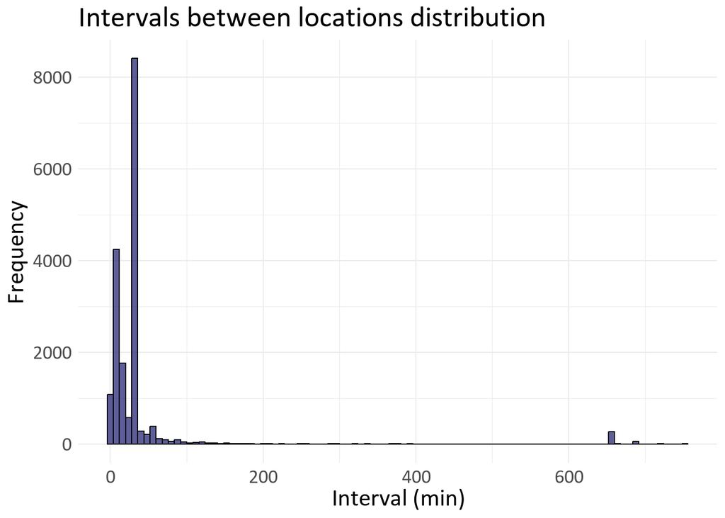

```r
ggplot(intervals_filtered, aes(x = interval_minutes)) +
  geom_histogram(binwidth = 8, fill = "midnightblue", color = "black", alpha = 0.7) +
  labs(
    title = "Intervals between locations distribution",
    x = "Interval (min)",
    y = "Frequency") +
  theme_minimal() +
  theme(text = element_text(family = 'Calibri', size =34))
```

```r
locs_full_day <- locs_clean_filtered %>%
  filter(daily_track_h > 8)

date_counts <- locs_full_day %>%
  group_by(area, id) %>%
  summarise(num_dates = n_distinct(date))

total_dates_by_area <- date_counts %>%
  group_by(area) %>%
  summarise(total_num_dates = sum(num_dates), .groups = "drop")
```

### 2.1 Calculating Steps

First I am creating the SF object to extract UTM coordinates ($X$ and $Y$), using complex number then I obtain $Z = X + iY$. The total daily trajectory includes the sum of all steps conducted within a same day. There are still some strange data that showed length above 7000 m, these days were removed becuase there were linked to location that not are from the monkeys (inside buildings for instance)

```r
locs_sf <- locs_full_day %>%
  st_as_sf(coords = c('lon', 'lat'), crs = 4326) %>%
  st_transform(crs = 32721)

locs_sf_coords <- st_coordinates(locs_sf)

locs_full_day <- locs_full_day %>%
  mutate(
    X = locs_sf_coords[,"X"],
    Y = locs_sf_coords[,"Y"],
    Z = X + 1i * Y
  )

steps_data <- locs_full_day %>%
  group_by(area, id, date) %>%
  arrange(t, .by_group = TRUE) %>%
  mutate(S = c(Mod(diff(Z)), NA)) %>%
  summarise(
    mean_S = mean(S, na.rm = TRUE),
    sd_S = sd(S, na.rm = TRUE),
    sum_S = sum(S, na.rm = TRUE),
    prop_plantations = mean(tipouso_grouped == "plantations", na.rm = TRUE),
    .groups = "drop"
  )

steps_data <- steps_data %>%
  filter(sum_S < 7000)
```

Exploring, little processing is still needed

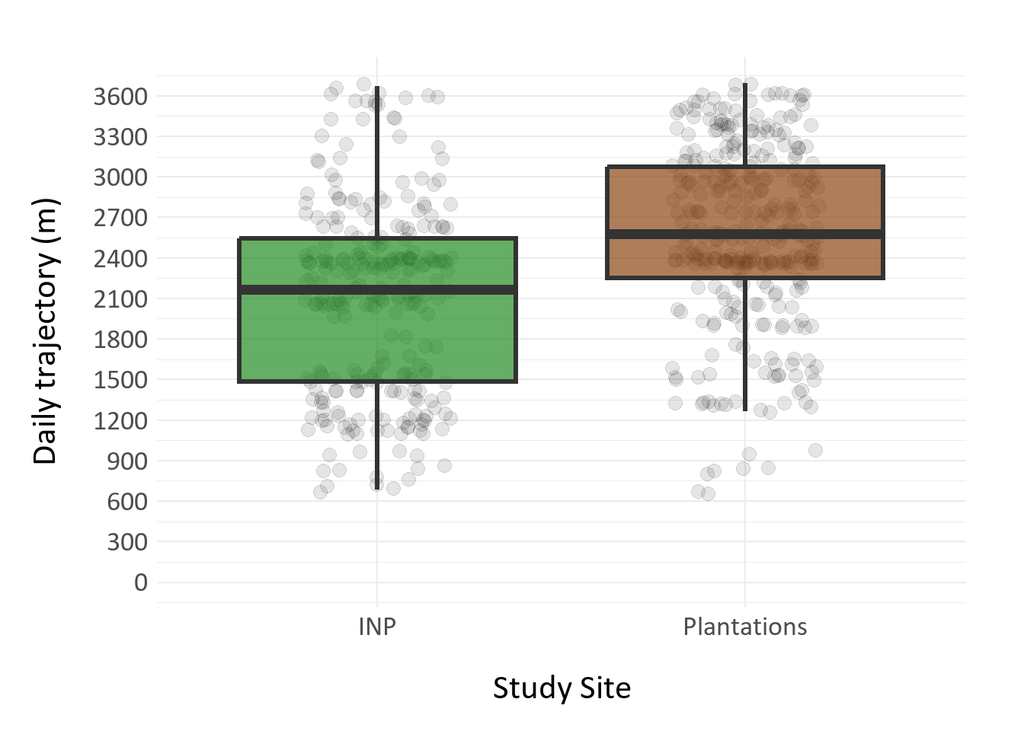

```r
steps_data <- steps_data %>%
  mutate(area = recode(area, "Arauco" = "Plantations", "PN Iguazu" = "INP"))

ggplot(steps_data, aes(x = area, y = sum_S, fill = area)) +
  geom_jitter(alpha = 0.1, width = 0.2, size= 3, height = 20) +
  geom_boxplot(alpha = 0.7, lwd = 1.2, outlier.shape = NA) +
  scale_fill_manual(values = c("Plantations" = "#8B4513", "INP" = "#228B22")) +
  scale_y_continuous(limits = c(0, 3700), breaks = seq(0, 3700, by = 300)) +
  labs(
    x = "Study Site",
    y = "Daily trajectory (m)") +
  theme_minimal() +
  theme(legend.position = "none",
        text = element_text(family = 'Calibri', size = 34),
        axis.title.x = element_text(vjust = -4),
        axis.title.y = element_text(vjust = 5),
        panel.background = element_rect(fill = "white", color = NA),
        plot.background = element_rect(fill = "white", color = NA),
        plot.margin = unit(c(1, 1, 1, 1), "cm"))
```

### 2.2 Speeds

```r
locs_full_day <- locs_full_day %>%
  mutate(
    speed = ifelse(!is.na(S) & !is.na(interval_minutes) & interval_minutes > 0, S / interval_minutes, NA))
```

```r
speed <- locs_full_day %>%
  group_by(area, id, date) %>%
  arrange(t, .by_group = TRUE) %>%
  summarise(
    mean_S = mean(speed, na.rm = TRUE),
    sd_S = sd(S, na.rm = TRUE),
    prop_plantations = mean(tipouso_grouped == "plantations", na.rm = TRUE),
    .groups = "drop")
```

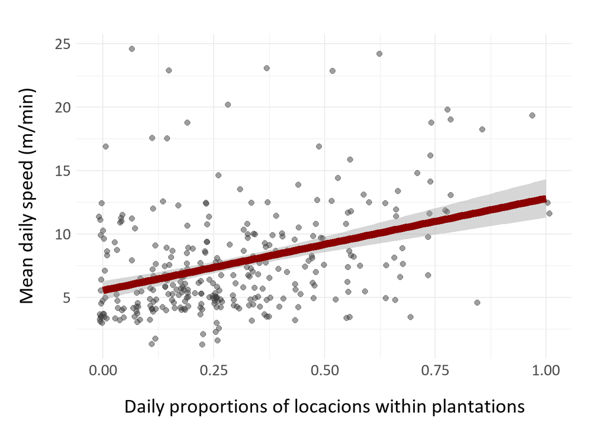

```r
speed %>%
  filter(area=='Plantations') %>%
  ggplot(aes(x = prop_plantations, y = speed)) +
  geom_jitter(width= 0.01, alpha = 0.5, size = 2, color = "grey24") +  # Puntos para cada día
  geom_smooth(method = "glm", color = "darkred", size = 3, se = TRUE) +
  labs(x = "Daily proportions of locacions within plantations",
    y = "Mean daily speed (m/min)"
  ) +
  theme_minimal() +
  theme(legend.position = "none",
        text = element_text(family = 'Calibri', size = 34),
        axis.title.x = element_text(vjust = -4),
        axis.title.y = element_text(vjust = 5),
        panel.background = element_rect(fill = "white", color = NA),
        plot.background = element_rect(fill = "white", color = NA),
        plot.margin = unit(c(1, 1, 1, 1), "cm"))
```

### 2.3 Suncalc estimations

```r
locs_first_last <- locs_full_day %>%
  group_by(id, date) %>%
  slice_min(order_by = t, n = 1) %>%
  mutate(time_label = "first") %>%
  bind_rows(
    locs_full_day %>%
      group_by(id, date) %>%
      slice_max(order_by = t, n = 1) %>%
      mutate(time_label = "last")
  ) %>%
  ungroup()

locs_full_day <- locs_full_day %>%
  mutate(date = as.Date(date))

get_sun_times <- function(date, lat, lon) {
  sun_times <- getSunlightTimes(
    date = date, lat = lat, lon = lon,
    keep = c("sunrise", "sunset"),
    tz = "America/Argentina/Buenos_Aires")
  return(sun_times)
}

sun_times_list <- pmap(
  list(locs_full_day$date, locs_full_day$lat, locs_full_day$lon),
  get_sun_times)

sun_data <- bind_rows(sun_times_list)

locs_full_day <- bind_cols(locs_full_day, sun_times_df)

locs_full_day <- locs_full_day %>%
  mutate(
    sunrise = format(sunrise, "%H:%M:%S"),
    sunset = format(sunset, "%H:%M:%S"))

locs_first_last <- locs_first_last %>%
  mutate(month_join = month(t))

sun_data <- sun_data %>%
  mutate(month_join = month(date))

locs_first_last <- locs_first_last %>%
  mutate(
    horario = format(t, format = "%H:%M:%S"))

sun_data <- sun_data %>%
  mutate(
    sunrise_horario = format(sunrise_datetime, format = "%H:%M:%S"),
    sunset_horario = format(sunset_datetime, format = "%H:%M:%S"))

sun_data <- sun_data %>%
  mutate(month_join = month(date)) %>%
  group_by(month_join) %>%
  slice(1) %>%
  ungroup() %>%
  mutate(
    sunrise_horario = format(sunrise_datetime, format = "%H:%M:%S"),
    sunset_horario = format(sunset_datetime, format = "%H:%M:%S"))


locs_with_sun_info <-
  locs_first_last %>%
  left_join(sun_data_unique, by = "month_join") %>%
  mutate(

    t_horario = as.POSIXct(paste("2024-01-01", horario)),
    sunrise_period = as.POSIXct(paste("2024-01-01", sunrise_horario)),
    sunset_period = as.POSIXct(paste("2024-01-01", sunset_horario)),

    t_to_sunrise = if_else(
      time_label == "first",
      as.numeric(difftime(
        t_horario,
        sunrise_period,
        units = "mins")),
      NA_real_),
    t_to_sunset = if_else(
      time_label == "last",
      as.numeric(difftime(
        sunset_period,
        t_horario,
        units = "mins")),
      NA_real_))

locs_with_sun_info <- locs_with_sun_info %>%
  dplyr::select(-sunrise_period, sunset_period, sunset,sunrise)

locs_with_sun_info <- locs_with_sun_info %>%
  mutate(
    time_to_sun = coalesce(t_to_sunrise, t_to_sunset)) %>%
  dplyr::select(-t_to_sunrise, -t_to_sunset)


locs_with_sun <- locs_with_sun_info %>%
  filter(time_to_sun >= -15 & time_to_sun <= 15)
```

### 2.4 Distances between sleeping sites (euclicean distances)

```r
locs_with_sun <- locs_with_sun %>%
  group_by(id, date.x) %>%
  mutate(
    X_first = na_if(first(X[time_label == "first"]), NA),
    Y_first = na_if(first(Y[time_label == "first"]), NA),
    X_last = na_if(first(X[time_label == "last"]), NA),
    Y_last = na_if(first(Y[time_label == "last"]), NA),

    distance_ss = if_else(
      !is.na(X_first) & !is.na(Y_first) & !is.na(X_last) & !is.na(Y_last),
      sqrt((X_last - X_first)^2 + (Y_last - Y_first)^2),
      NA_real_
    )
  ) %>%
  ungroup() %>%
  dplyr::select(-X_first, -Y_first, -X_last, -Y_last)
```

Checking some specific data

```r
demos1 <- locs_full_day %>%
  filter((id == "gua.may.22" & date == as.Date("2022-05-25")))%>%
  mutate(hour = hour(t))

demos2 <- locs_full_day %>%
           filter((id == "gun.nov.10" & date == as.Date("2010-11-22")))%>%
  mutate(hour = hour(t))


sf_demos1 <- st_as_sf(demos1, coords = c("lon", "lat"), crs = 4326)
sf_demos2 <- st_as_sf(demos2, coords = c("lon", "lat"), crs = 4326)


first_point1 <- sf_demos1 %>% filter(t == min(t))
last_point1 <- sf_demos1 %>% filter(t == max(t))

first_point1_utm <- st_transform(first_point1, crs = 32721)
last_point1_utm <- st_transform(last_point1, crs = 32721)

distance_meters1 <- st_distance(first_point1_utm, last_point1_utm)
distance_meters1 <- as.numeric(distance_meters1)

mid_x <- (st_coordinates(first_point1)[1,1] + st_coordinates(last_point1)[1,1]) / 2
mid_y <- (st_coordinates(first_point1)[1,2] + st_coordinates(last_point1)[1,2]) / 2



first_point2 <- sf_demos2 %>% filter(t == min(t))
last_point2 <- sf_demos2 %>% filter(t == max(t))

first_point2_utm <- st_transform(first_point2, crs = 32721)
last_point2_utm <- st_transform(last_point2, crs = 32721)

distance_meters2 <- st_distance(first_point2_utm, last_point2_utm)
distance_meters2 <- as.numeric(distance_meters2)

mid_x2 <- (st_coordinates(first_point2)[1,1] + st_coordinates(last_point2)[1,1]) / 2
mid_y2 <- (st_coordinates(first_point2)[1,2] + st_coordinates(last_point2)[1,2]) / 2

sf_demos1_df <- sf_demos1 %>%
  mutate(lon = st_coordinates(.)[,1], lat = st_coordinates(.)[,2])

sf_demos2_df <- sf_demos2 %>%
  mutate(lon = st_coordinates(.)[,1], lat = st_coordinates(.)[,2])
```

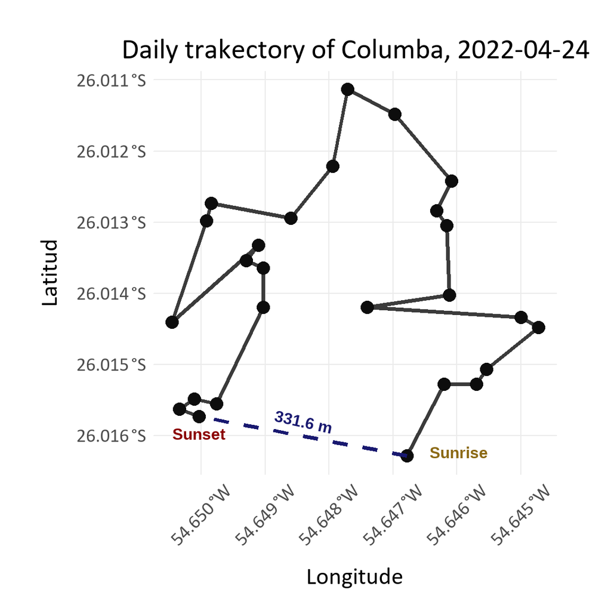

```r
ggplot() +
  geom_path(data = sf_demos1_df, aes(x = lon, y = lat), color = "grey23", size = 1.4, linetype = "solid") +
  geom_sf(data = sf_demos1, size = 4, color = "grey5") +
  geom_segment(data = NULL,
               aes(x = st_coordinates(first_point1)[1,1],
                   y = st_coordinates(first_point1)[1,2],
                   xend = st_coordinates(last_point1)[1,1],
                   yend = st_coordinates(last_point1)[1,2]),
               color = "midnightblue", linetype = "dashed", size = 1.4) +
  annotate("text", x = mid_x, y = mid_y + 0.0002, label = paste0(round(distance_meters1, 1), " m"),
           color = "midnightblue", size = 8, angle = -12.5, fontface = "bold") +
  annotate("text", x = st_coordinates(first_point1)[1,1] + 0.0008,
           y = st_coordinates(first_point1)[1,2] + 0.00005,
           label = "Sunrise", color = "goldenrod4", size = 8, fontface = "bold") +
  annotate("text", x = st_coordinates(last_point1)[1,1],
           y = st_coordinates(last_point1)[1,2] - 0.00025,
           label = "Sunset", color = "darkred", size = 8, fontface = "bold") +
  labs(title = "Daily trakectory of Columba, 2022-04-24",
       x = "Longitude",
       y = "Latitud") +
  theme_minimal() +
  theme(axis.text.x = element_text(angle = 45, vjust = 0.5),
        legend.position = "top",
        legend.title = element_blank(),
        text = element_text(family = 'Calibri', size = 34),
        plot.title = element_text(hjust = 0.5),
        axis.title.x = element_text(vjust = -3),
        axis.title.y = element_text(vjust = 4),
        panel.background = element_rect(fill = "white", color = NA),
        plot.background = element_rect(fill = "white", color = NA),
        plot.margin = unit(c(1, 1, 1, 1), "cm"))
```

We will keep only complete tracking days, defined as days with eight evenly spaced locations recorded at 90-minute intervals (±15 minutes).

```r
locs_day <- locs_with_sun %>%
  group_by(id, date) %>%
  mutate(
    time_diff = difftime(t, lag(t), units = "mins"),
    valid_intervals = sum(abs(time_diff - 90) <= 15, na.rm = TRUE)) %>%
  filter(n() == 8 & valid_intervals == 7) %>%
  ungroup()
```

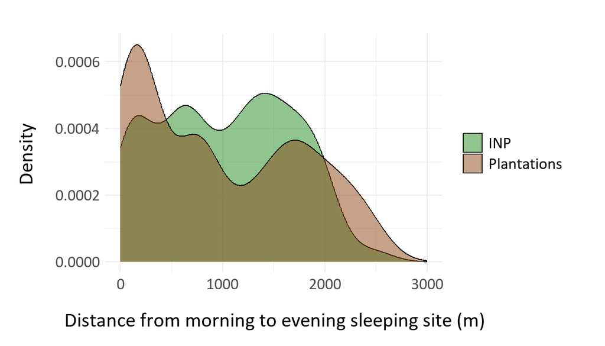

```r
ggplot(locs_with_sun, aes(x = distance_ss, fill = area)) +
  geom_density(alpha = 0.5) +
  scale_fill_manual(values = c("Plantations" = "#8B4513", "INP" = "#228B22")) +
  scale_y_continuous(labels = scales::comma)+
  scale_x_continuous(limits = c(0,3000))+
  labs(
    x = "Distance from morning to evening sleeping site (m)",
    y = "Density")+
    guides(fill = guide_legend(title = NULL)) +
  theme_minimal()+
  theme(text = element_text(family = 'Calibri', size = 34),
        axis.title.x = element_text(vjust = -4),
        axis.title.y = element_text(vjust = 5),
        panel.background = element_rect(fill = "white", color = NA),
        plot.background = element_rect(fill = "white", color = NA),
        plot.margin = unit(c(1, 1, 1, 1), "cm"))
```

### 2.5 Wheather Covariates

Minimum, mean and maximum daily temperature and precipitation (obtained for the Iguazú International Airport by the National Meteorological Service of Argentina), as these climatic factors may influence primate movement patterns [(Asensio et al., 2012)](https://link.springer.com/article/10.1007/s10329-011-0288-9)

```r
snm <- read_csv('igua_aero.csv')

snm$date <- as.Date(snm$date, format = "%d/%m/%Y")

locs_day <- locs_day %>%
  left_join(snm, by = "date")
```

## 3 GLMM models

```r
colores <- c('Plantations' = 'orange3', 'INP' = 'palegreen4')
colores2 <- c('Plantations' = '#f3c554', 'INP' = '#afeeb3')
```

### 3.1 Response variable distribution

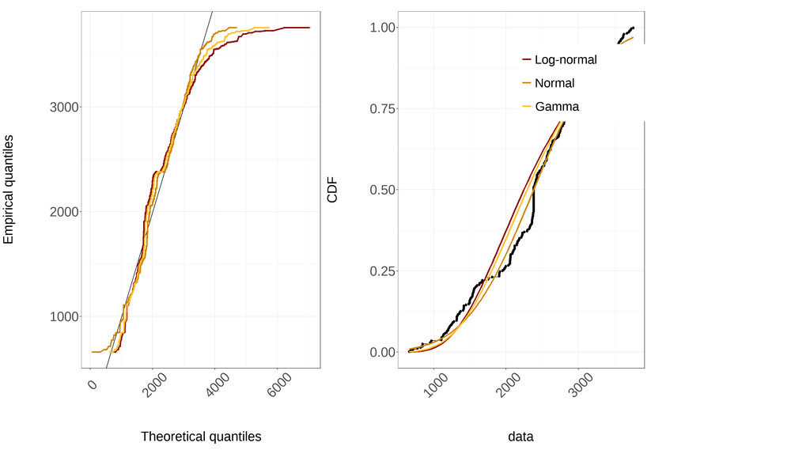

```r
normal_fit <- fitdist(locs_day$sum_S2, "norm")
lognormal_fit <- fitdist(locs_day$sum_S2, "lnorm")
gamma_fit <- fitdist(locs_day$sum_S2, "gamma")

cdf_sum_S2 <- cdfcomp(
  list(lognormal_fit, normal_fit, gamma_fit),
  main = "",
  legendtext = c("Log-normal", "Normal", "Gamma"),
  fitcol = c("darkred", "orange3", "goldenrod1"),
  plotstyle = "ggplot") +
  geom_line(size = 1.2) +
  theme(
    axis.title = element_text(size = 42),
    axis.text = element_text(size = 42),
    axis.text.x = element_text(angle = 45, vjust = 0.8),
    legend.position = c(0.8, 0.8),
    legend.text = element_text(size = 40))

qq_sum_S2 <- qqcomp(
  list(lognormal_fit, normal_fit, gamma_fit),
  main = "",
  fitcol = c("darkred", "orange3", "goldenrod1"),
  plotstyle = "ggplot") +
  geom_line(size = 1.2) +
  theme_bw() +
  theme(
    axis.title = element_text(size = 42),
    axis.text = element_text(size = 42),
    axis.text.x = element_text(angle = 45, vjust = 0.8),
    legend.position = "none")

plot_grid(qq_sum_S2, cdf_sum_S2, NULL, ncol = 3, rel_widths = c(1.5, 1.5, 0.75))
```

```r
aic_values <- data.frame(
  Distribution = c("Normal", "Lognormal", "Gamma"),
  AIC = c(normal_fit$aic, lognormal_fit$aic, gamma_fit$aic)) %>%
  mutate(deltaAIC = AIC - min(AIC)) %>%
  arrange(AIC)

aic_table <- aic_values %>%
  flextable() %>%
  theme_tron_legacy() %>%
  colformat_num(j = c("AIC", "deltaAIC"), digits = 3) %>%
  bold(part = "header") %>%
  autofit()

aic_table
```

| Distribution | AIC | deltaAIC |
| --- | --- | --- |
| Normal | 9,726.277 | 0.00000 |
| Gamma | 9,786.895 | 60.61803 |
| Lognormal | 9,848.748 | 122.47118 |

**AIC table** Best fit distributions for response variable (daily travel)

```r
locs_day <- locs_day %>%
  mutate(
    distance_ss_scaled = scale(distance_ss, center = TRUE, scale = TRUE),
    t_mean_scaled = scale(t_mean, center = TRUE, scale = TRUE),
    precip_scaled = scale(precip, center = TRUE, scale = TRUE),
    t_min_scaled = scale(t_min, center = TRUE, scale = TRUE))

locs_day <- locs_day %>%
  mutate(food = case_when(
    estacion2 == "invierno" ~ "low",
    TRUE ~ "high"))
```

### 3.2 Models

```r
m0 <- lmer(sum_S2 ~ 1 + (1 | grupo), data = locs_day)
m1 <- lmer(sum_S2 ~ area + (1 | grupo), data = locs_day)
m2 <- lmer(sum_S2 ~ area + distance_ss_scaled + (1 | grupo), data = locs_day)
m3 <- lmer(sum_S2 ~ area * distance_ss_scaled + (1 | grupo), data = locs_day)
m4 <- lmer(sum_S2 ~ area * food + distance_ss_scaled +  (1 | grupo), data = locs_day)
m5 <- lmer(sum_S2 ~ area * distance_ss_scaled + food +  (1 | grupo), data = locs_day)
m6 <- lmer(sum_S2 ~ area + t_min_scaled + (1 | grupo), data = locs_day)
m7 <- lmer(sum_S2 ~ area + t_min_scaled + precip_scaled + (1 | grupo), data = locs_day)
m8 <- lmer(sum_S2 ~ area + distance_ss_scaled + t_min_scaled + precip_scaled + (1 | grupo), data = locs_day)
m9 <- lmer(sum_S2 ~ area * distance_ss_scaled + t_min_scaled + precip_scaled + (1 | grupo), data = locs_day)
m10 <- lmer(sum_S2 ~ area  + precip_scaled + distance_ss_scaled + t_min_scaled + (1 | grupo), data = locs_day)
m11 <- lmer(sum_S2 ~ area + t_min_scaled * distance_ss_scaled + precip_scaled + (1 | grupo), data = locs_day)
m12 <- lmer(sum_S2 ~ area * distance_ss_scaled + food + t_min_scaled + precip_scaled + (1 | grupo), data = locs_day)
m13 <- lmer(sum_S2 ~ area + distance_ss_scaled + food + t_min_scaled + precip_scaled + (1 | grupo), data = locs_day)
m14 <- lmer(sum_S2 ~ area * distance_ss_scaled + precip_scaled + (1 | grupo), data = locs_day)
m15 <- lmer(sum_S2 ~ area * food + t_min_scaled + (1 | grupo), data = locs_day)
m16 <- lmer(sum_S2 ~ area + distance_ss_scaled + food + daily_length + precip_scaled + (1 | grupo), data = locs_day)
m17 <- lmer(sum_S2 ~ area * distance_ss_scaled + daily_length + (1 | grupo), data = locs_day)
m18 <- lmer(sum_S2 ~ area * food + daily_length + t_min_scaled + (1 | grupo), data = locs_day)
m19 <- lmer(sum_S2 ~ area * daily_length + distance_ss_scaled + food + precip_scaled + (1 | grupo), data = locs_day)
m20 <- lmer(sum_S2 ~ area * daily_length * distance_ss_scaled + food + precip_scaled + (1 | grupo), data = locs_day)
m21<- lmer(sum_S2 ~ area * distance_ss_scaled + daily_length + food + t_min_scaled + precip_scaled + (1 | grupo), data = locs_day)
```

### 3.3 AIC comparisons

```r
model_aic <- AIC(m0, m1, m2, m3, m4, m5, m6, m7, m8, m9, m10, m11, m12, m13, m14, m15, m16, m17, m18, m19, m20, m21)

model_aic$deltaAIC <- model_aic$AIC - min(model_aic$AIC)

model_aic$Rank <- rank(model_aic$deltaAIC, ties.method = "first")

model_aic$Model <- c(
  "Null model", #m0
  "Study site", #m1
  "Study site + Sleeping Sites Distance", #m2
  "Study site * Sleeping Sites Distance", #m3
  "Study site + Fruit Season + Sleeping Sites Distance", #m4
  "Study site * Sleeping Sites Distance + Fruit Season", #m5
  "Study site + Min. Temperature", #m6
  "Study site + Min. Temperature + Precipitation", #m7
  "Study site + Sleeping Sites Distance + Min. Temperature + Precipitation", #m8
  "Study site * Sleeping Sites Distance + Min. Temperature + Precipitation", #m9
  "Study site + Sleeping Sites Distance + Min. Temperature + Precipitation", #m10
  "Study site + Min. Temperature * Sleeping Sites Distance + Precipitation", #m11
  "Study site * Sleeping Sites Distance + Fruit Season + Min. Temperature + Precipitation", #m12
  "Study site + Sleeping Sites Distance + Fruit Season + Min. Temperature + Precipitation", #m13
  "Study site * Sleeping Sites Distance + Precipitation", #m14
  "Study site * Fruit Season + Min. Temperature", #m15
  "Study site + Sleeping Sites Distance + Fruit Season + Daily Length + Precipitation", #m16
  "Study site * Sleeping Sites Distance + Daily Length", #m17
  "Study site * Fruit Season + Daily lenght + Min. Temperature", #m18
  "Study site * Daily length + Sleeping Sites Distance + Fruit Season + Precipitation", #m19
  "Study site * Daily length * Sleeping Sites Distance + Fruit Season + Precipitation", #m20
  "Study site * Sleeping Sites Distance + Daily Length + Fruit Season + Min. Temperature + Precipitation") #m21

model_table <- model_aic[order(model_aic$Rank), c("Rank", "Model", "df", "AIC", "deltaAIC")]
model_table <- model_table %>% arrange(Rank)

model_table %>%
  flextable() %>%
  theme_tron_legacy() %>%
  colformat_num(j = c("AIC", "deltaAIC"), digits = 3) %>%
  bold(part = "header") %>%
  set_caption("AIC Model Comparison for Study Site Effects") %>%
  autofit()
```

AIC Model Comparison for Study Site Effects

| Rank | Model | df | AIC | deltaAIC |
| --- | --- | --- | --- | --- |
| 1 | Study site * Sleeping Sites Distance + Daily Length + Fruit Season + Min. Temperature + Precipitation | 10 | 9,467.830 | 0.000000 |
| 2 | Study site * Sleeping Sites Distance + Fruit Season + Min. Temperature + Precipitation | 9 | 9,475.603 | 7.772724 |
| 3 | Study site * Sleeping Sites Distance + Min. Temperature + Precipitation | 8 | 9,488.406 | 20.576256 |
| 4 | Study site * Fruit Season + Daily lenght + Min. Temperature | 8 | 9,503.292 | 35.462014 |
| 5 | Study site + Sleeping Sites Distance + Fruit Season + Min. Temperature + Precipitation | 8 | 9,508.242 | 40.412077 |
| 6 | Study site * Fruit Season + Min. Temperature | 7 | 9,511.325 | 43.494519 |
| 7 | Study site + Min. Temperature * Sleeping Sites Distance + Precipitation | 8 | 9,513.471 | 45.641324 |
| 8 | Study site + Sleeping Sites Distance + Min. Temperature + Precipitation | 7 | 9,520.213 | 52.383413 |
| 9 | Study site + Sleeping Sites Distance + Min. Temperature + Precipitation | 7 | 9,520.213 | 52.383413 |
| 10 | Study site + Min. Temperature + Precipitation | 6 | 9,527.070 | 59.239589 |
| 11 | Study site + Min. Temperature | 5 | 9,533.672 | 65.842111 |
| 12 | Study site * Daily length * Sleeping Sites Distance + Fruit Season + Precipitation | 12 | 9,550.382 | 82.552308 |
| 13 | Study site * Sleeping Sites Distance + Fruit Season | 7 | 9,595.433 | 127.603250 |
| 14 | Study site * Sleeping Sites Distance + Daily Length | 7 | 9,599.418 | 131.588258 |
| 15 | Study site * Daily length + Sleeping Sites Distance + Fruit Season + Precipitation | 9 | 9,600.521 | 132.691392 |
| 16 | Study site * Sleeping Sites Distance + Precipitation | 7 | 9,600.847 | 133.016548 |
| 17 | Study site * Sleeping Sites Distance | 6 | 9,608.300 | 140.469961 |
| 18 | Study site + Sleeping Sites Distance + Fruit Season + Daily Length + Precipitation | 8 | 9,613.366 | 145.535870 |
| 19 | Study site + Fruit Season + Sleeping Sites Distance | 7 | 9,617.597 | 149.766521 |
| 20 | Study site + Sleeping Sites Distance | 5 | 9,640.340 | 172.510322 |
| 21 | Study site | 4 | 9,647.128 | 179.298477 |
| 22 | Null model | 3 | 9,666.865 | 199.035172 |

### 3.4 Best Model summary

```r
summary(m21)
```

```
## Linear mixed model fit by REML ['lmerMod']
## Formula:
## sum_S2 ~ area * distance_ss_scaled + daily_length + food + t_min_scaled +
##     precip_scaled + (1 | grupo)
##    Data: locs_day
##
## REML criterion at convergence: 9447.8
##
## Scaled residuals:
##      Min       1Q   Median       3Q      Max
## -2.88224 -0.70006  0.09481  0.64915  2.67262
##
## Random effects:
##  Groups   Name        Variance Std.Dev.
##  grupo    (Intercept)   3839    61.96
##  Residual             473853   688.37
## Number of obs: 599, groups:  grupo, 8
##
## Fixed effects:
##                                    Estimate Std. Error t value
## (Intercept)                        2283.761    635.102   3.596
## areaPlantations                     403.969     86.748   4.657
## distance_ss_scaled                  140.085     40.217   3.483
## daily_length                        -17.739     49.644  -0.357
## foodlow                             158.756     89.674   1.770
## t_min_scaled                          6.509     35.733   0.182
## precip_scaled                        35.505     29.682   1.196
## areaPlantations:distance_ss_scaled -318.562     63.795  -4.993
##
## Correlation of Fixed Effects:
##             (Intr) arPlnt dstn__ dly_ln foodlw t_mn_s prcp_s
## areaPlnttns -0.422
## dstnc_ss_sc -0.065  0.178
## daily_lngth -0.996  0.364  0.040
## foodlow     -0.426  0.076  0.032  0.409
## t_min_scald  0.366  0.039 -0.044 -0.389  0.144
## precip_scld -0.016 -0.146  0.132  0.022  0.074 -0.153
## arPlnttn:__  0.035  0.050 -0.649 -0.020 -0.059  0.049 -0.226
```

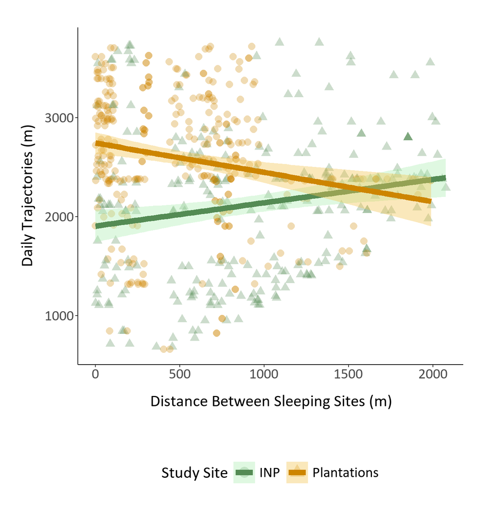

```r
s2_dss_raw <-
  ggplot(locs_day,
         aes(x = distance_ss,
             y = sum_S2,
             color = area)) +
  geom_point(
    aes(shape = area),
    size = 3.2,
    alpha = 0.3) +
  geom_smooth(
    aes(fill = area), method = "lm",
              se = TRUE,
              linewidth = 2.8) +
  scale_color_manual(values = colores,
                     name = "Study Site") +
  scale_fill_manual(values = colores2,
                    name = "Study Site") +
  scale_shape_manual(
    values = c("Plantations" = 16, "INP" = 17),
    name = "Study Site") +
  labs(
    x = "Distance Between Sleeping Sites (m)",
    y = "Daily Trajectories (m)") +
  guides(
    color = guide_legend(
      override.aes = list(
        shape = c(16, 17),
        size = 5)),
    shape = "none") +
  theme_classic() +
  theme(
    text = element_text(family = 'Calibri', size = 34),
    legend.position = 'bottom',
    legend.box.margin = margin(t = 50, b = 10),
    legend.title = element_text(size = 34),
    legend.text = element_text(size = 30),
    legend.key.size = unit(1.5, "lines"),
    legend.spacing.x = unit(0.5, "cm"),
    legend.spacing.y = unit(0.3, "cm"),
    axis.title.x = element_text(size = 34, vjust = -3),
    axis.title.y = element_text(size = 34, vjust = 3),
    axis.text = element_text(size = 30),
    plot.margin = unit(c(1, 1, 1, 1), 'cm'))
s2_dss_raw
```

```r
r_squared <- r.squaredGLMM(m21)

r_squared <- data.frame(
  Metric = c("Marginal R² (R²m)", "Conditional R² (R²c)"),
  Value = c(r_squared[1, 1], r_squared[1, 2]))

r_squared %>%
  flextable() %>%
  colformat_num(j = "Value", digits = 2) %>%
  set_caption("R² Values for best model - capuchins daily trajectories") %>%
  bold(part = "header") %>%
  autofit()
```

R² Values for best model - capuchins daily trajectories

[output not shown]

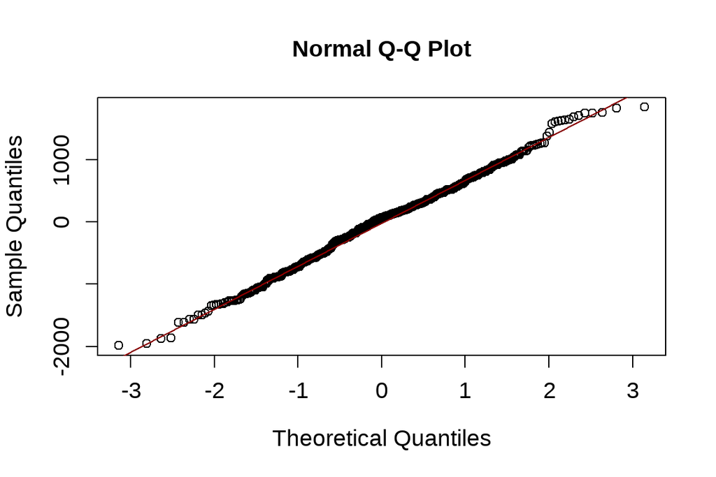

```r
qqnorm(residuals(m21), cex = 1,
       cex.axis = 2.3,
       cex.lab = 2.3,
       cex.main = 2.3)

qqline(residuals(m21), col='darkred', cex=9)
```

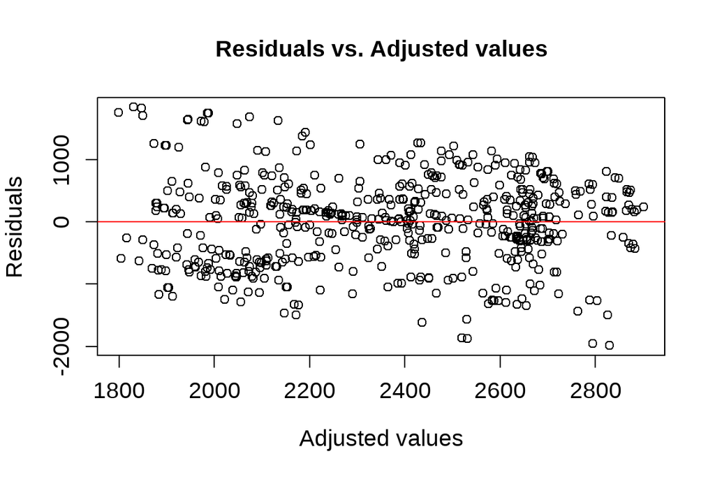

```r
plot(fitted(m21), residuals(m21),
     xlab = "Adjusted values", ylab = "Residuals",
     main = "Residuals vs. Adjusted values",
     cex.lab = 2.3,
     cex.main = 2.3,
     cex.axis = 2.3)

abline(h = 0, col = "red")
```

```r
set.seed(123)


folds <- createFolds(locs_day$sum_S2, k = 10, list = TRUE)


errors <- numeric(length(folds))


for (i in seq_along(folds)) {
  train_data <- locs_day[-folds[[i]], ]
  test_data <- locs_day[folds[[i]], ]


  model <- lmer(sum_S2 ~ area * distance_ss_scaled + food + t_min_scaled +
                  precip_scaled + (1 | grupo),
                data = train_data)  # Aquí usamos train_data


  predictions <- predict(model, newdata = test_data, allow.new.levels = TRUE)


  errors[i] <- mean((predictions - test_data$sum_S2)^2, na.rm = TRUE)
}

mean_cv_error <- mean(errors, na.rm = TRUE)
cat("RMSE cross-validation:", sqrt(mean_cv_error), "\n")
```

```
## RMSE cross-validation: 692.1672
```

```r
model_no_random <- lm(sum_S2 ~ area * distance_ss_scaled + food + t_min_scaled + precip_scaled,
                      data = locs_day)

errors_no_random <- numeric(length(folds))

for (i in seq_along(folds)) {
  train_data <- locs_day[-folds[[i]], ]
  test_data <- locs_day[folds[[i]], ]

  model <- lm(sum_S2 ~ area * distance_ss_scaled + food + t_min_scaled + precip_scaled,
              data = train_data)

  predictions <- predict(model, newdata = test_data)

  errors_no_random[i] <- mean((predictions - test_data$sum_S2)^2, na.rm = TRUE)
}

mean_cv_error_no_random <- mean(errors_no_random, na.rm = TRUE)
cat("Mean RMSE without random effect:", sqrt(mean_cv_error_no_random), "\n")
```

```
## Mean RMSE without random effect: 692.2336
```

### 3.5 Plantaions groups - Bark stripping

```r
locs_day_pine <- locs_day %>% filter(area == 'Plantations')

dano <- read_csv ('files/dano_nuevo_area.csv')

dano <- dano %>%
  separate(mes,
           into = c("mes", "day"),
           sep = "-")
```

```r
dano <- dano %>%
  rename(year= day)

dano <- dano  %>%
  mutate(year = paste0("20", year))

dano$grupo <- factor(dano$grupo,
                     levels = c('Grupo 1', 'Grupo 2', 'Grupo 3', 'Grupo 4'),
                     labels = c('Columba', 'Pandemia', 'Triangulo', 'Gualicho'))

monthly_dano <- dano %>%
  group_by(grupo, mes, year) %>%
  summarise(media_dano = mean(m2, na.rm = TRUE))

monthly_dano$year <- as.integer(monthly_dano$year)

monthly_dano <- monthly_dano %>%
  rename(month = mes)

locs_day_pine$year <- as.integer(locs_day_pine$year)

locs_day_pine <- locs_day_pine %>%
  left_join(monthly_dano, by = c("grupo" = "grupo", "month" = "month", "year" = "year"))
```

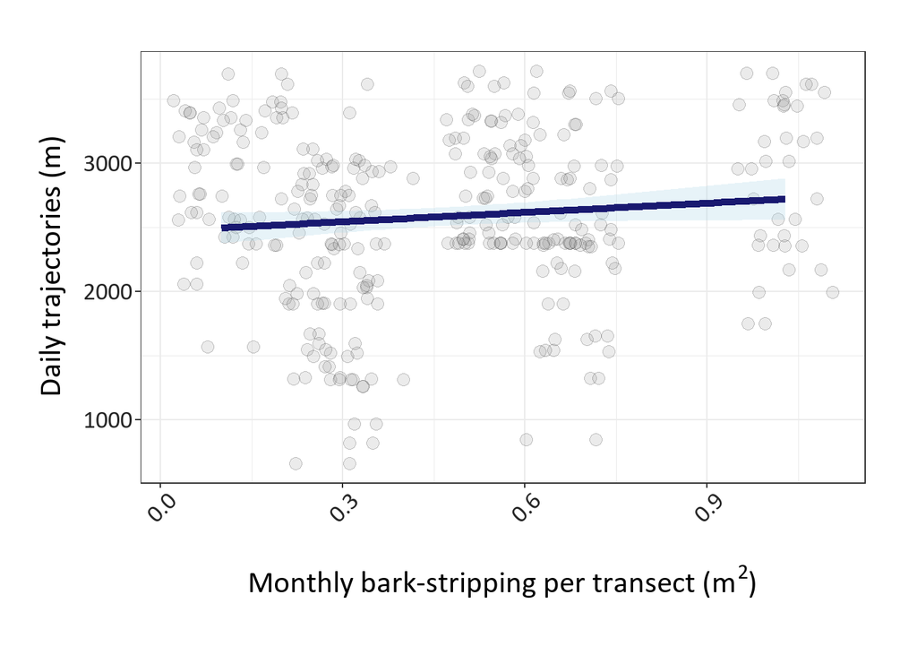

```r
ggplot(locs_day_pine, aes(x = media_dano, y = sum_S2)) +
  geom_jitter(
    size = 3,
    alpha = 0.2,
    color = 'black',
    shape = 21,
    fill = 'grey60',
    width = 0.08,
    height = 0.1) +
  geom_smooth(
    method = "lm",
    linewidth = 1.8,
    color = "midnightblue",
    fill = "lightblue",
    se = TRUE,
    alpha = 0.3) +
  labs(
    y = "Daily trajectories (m)",
    x = expression("Monthly bark-stripping per transect (m"^2*")")) +
  theme_bw() +
  guides(
    size = "none",
    alpha = "none",
    color = "none") +
  theme(
    text = element_text(family = "Calibri", size = 34),
    axis.text.x = element_text(color = "grey15", angle = 45, hjust = 0.5, vjust = 0.6),
    axis.text.y = element_text(color = "grey15"),
    axis.title.x = element_text(face = "bold", margin = margin(t = 20)),
    axis.title.y = element_text(face = "bold", vjust = 3),
    plot.margin = unit(c(1, 1, 1, 1), "cm"))
```

```r
cor_test_result <- cor.test(locs_day_pine$media_dano, locs_day_pine$sum_S2,
                            method = "pearson", use = "complete.obs")
print(cor_test_result)
```

```
##
##  Pearson's product-moment correlation
##
## data:  locs_day_pine$media_dano and locs_day_pine$sum_S2
## t = 1.8221, df = 329, p-value = 0.06934
## alternative hypothesis: true correlation is not equal to 0
## 95 percent confidence interval:
##  -0.007931638  0.205539895
## sample estimates:
##        cor
## 0.09995422
```

```r
# Extraer resultados relevantes
correlation_coefficient <- cor_test_result$estimate
p_value <- cor_test_result$p.value
n_obs <- cor_test_result$parameter + 2
```